# Low-Rank Methods in Practice

Word embeddings and image compression with singular value decomposition

Author

Hengru (Fiona) Zhou

## Project overview

This project explores two applications of singular value decomposition (SVD):

1. Learning low-dimensional word embeddings from a word co-occurrence matrix.
2. Compressing a grayscale image using low-rank matrix approximations.

The text analysis uses the six novels included in the `janeaustenr` package. Words that occur within a five-word window are recorded in a weighted co-occurrence matrix. The 3,000 most frequent non-stopwords are retained.

## Word embeddings

and approximated using the top 100 singular components. The resulting word vectors are normalized so cosine similarity can be used to compare words.

### Singular values

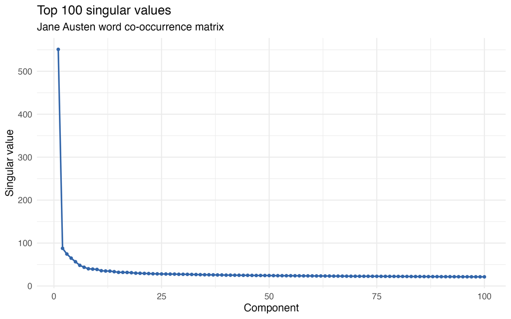

The rapid initial decline indicates that a relatively small number of components captures a substantial portion of the matrix structure. Later components contribute progressively smaller refinements.

### Nearest neighbours

|  | Target | Neighbour | Cosine similarity |
| --- | --- | --- | --- |
| 1 | love | believed | 0.5190 |
| 2 | love | falling | 0.4971 |
| 3 | love | loved | 0.4883 |
| 4 | love | fancy | 0.4777 |
| 5 | love | heart | 0.4675 |
| 6 | love | marry | 0.4655 |
| 7 | love | believe | 0.4653 |
| 8 | love | affection | 0.4544 |
| 9 | love | attachment | 0.4525 |
| 10 | love | satisfied | 0.4484 |
| 11 | marriage | married | 0.5041 |
| 12 | marriage | marrying | 0.4927 |
| 13 | marriage | marry | 0.4640 |
| 14 | marriage | choice | 0.4405 |
| 15 | marriage | event | 0.4366 |
| 16 | marriage | match | 0.4148 |
| 17 | marriage | circumstance | 0.4148 |
| 18 | marriage | fortunate | 0.4115 |
| 19 | marriage | possibility | 0.4043 |
| 20 | marriage | happiness | 0.4008 |
| 41 | elizabeth | darcy | 0.6021 |
| 42 | elizabeth | bennet | 0.5956 |
| 43 | elizabeth | bingley | 0.5746 |
| 44 | elizabeth | jane | 0.5285 |
| 45 | elizabeth | catherine | 0.5012 |
| 46 | elizabeth | collins | 0.4822 |
| 47 | elizabeth | lydia | 0.4727 |
| 48 | elizabeth | wickham | 0.4716 |
| 49 | elizabeth | pemberley | 0.4606 |
| 50 | elizabeth | kitty | 0.4463 |
| 51 | darcy | bingley | 0.7218 |
| 52 | darcy | elizabeth | 0.6021 |
| 53 | darcy | wickham | 0.5429 |
| 54 | darcy | collins | 0.5409 |
| 55 | darcy | bennet | 0.5229 |
| 56 | darcy | pemberley | 0.5182 |
| 57 | darcy | fitzwilliam | 0.5079 |
| 58 | darcy | lydia | 0.4767 |
| 59 | darcy | civility | 0.4748 |
| 60 | darcy | charlotte | 0.4616 |

The model recovers several intuitive relationships. Words such as `affection`, `attachment`, and `heart` appear near `love`, while major characters from *Pride and Prejudice* form a recognizable cluster around `elizabeth` and `darcy`.

## Gender associations

A gender direction is estimated by averaging several normalized differences, including `woman - man`, `girl - boy`, and `wife - husband`.

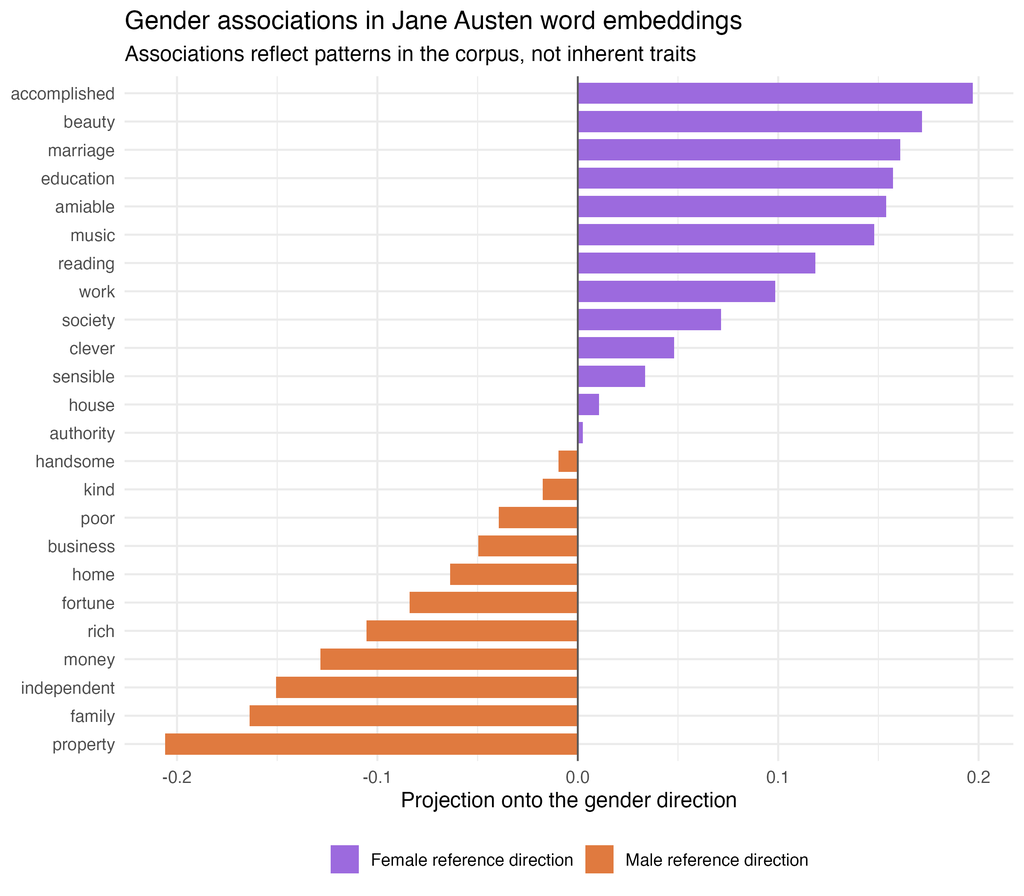

These projections describe patterns in this particular literary corpus. They should not be interpreted as inherent characteristics of people or concepts. The results can reflect historical language, character roles, and the limited scope of the novels.

## Image compression

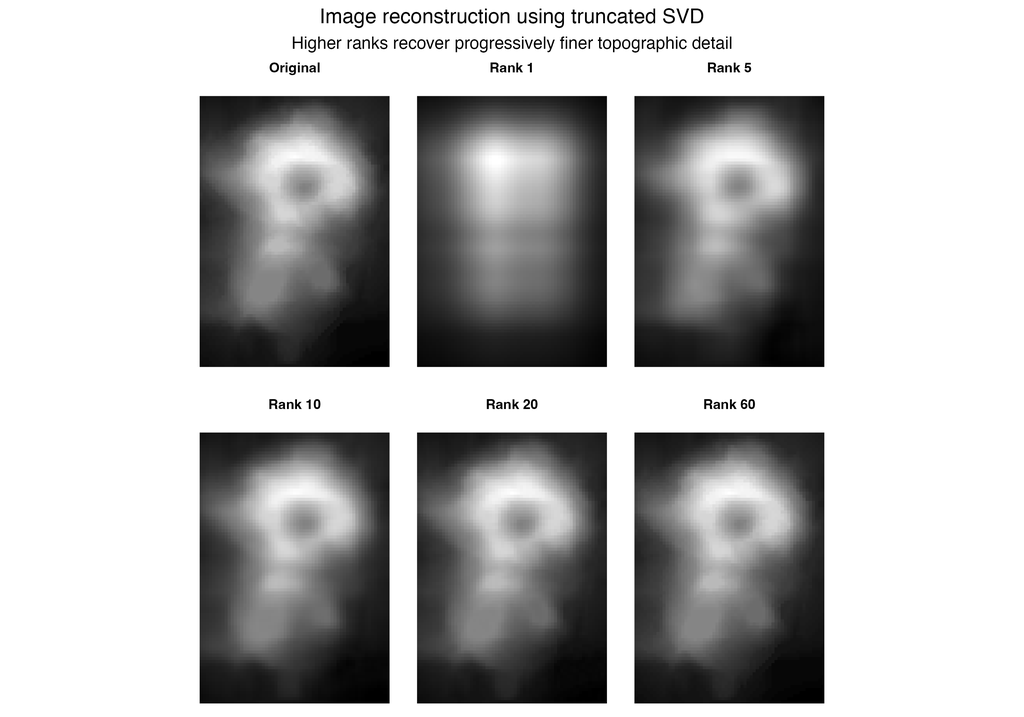

| Rank | Relative error | Stored values | Storage saving |
| --- | --- | --- | --- |
| 1 | 18.1% | 149 | 97.19% |
| 3 | 6.22% | 447 | 91.58% |
| 5 | 3.33% | 745 | 85.96% |
| 10 | 1.45% | 1490 | 71.92% |
| 20 | 0.78% | 2980 | 43.85% |
| 40 | 0.3% | 5960 | -12.3% |
| 60 | 0.03% | 8940 | -68.46% |

A rank-10 approximation reduces storage by approximately 72% while keeping relative reconstruction error near 1.45%. At sufficiently high ranks, the factorized representation becomes larger than the original matrix.

## Limitations

The text results depend on the corpus, vocabulary size, context window, stopword list, and embedding dimension. Jane Austen’s novels represent a specific historical and literary setting, so conclusions should not be generalized to modern language or society.

The image example illustrates low-rank approximation on a small topographic matrix. Performance on photographs and other complex images may differ.

## Reproducibility

Run the scripts in numerical order:

```
R/01_build_corpus.R
R/02_fit_embeddings.R
R/03_explore_embeddings.R
R/04_analyze_gender_associations.R
R/05_image_compression.R
```